# 历史让平发生率能否校正FM-1.7.1：三期滚动诊断

## 研究范围与因果限制

检验历史让平发生率能否修正FM-1.7.1对让平的系统性偏差，并返调完整比分，使让胜、让负比例与完整净胜球分布保持一致。不是要求让平必进Top2，也不只用漏保让平作训练。

可复用的FM-1.7.1同版历史仅有26098、26101、26102三期323场预测、322场有效赛果。23场原生同赛事支持不足的父版留存行不训练、不评分；取消场次有预测但无标签、不入训练或评分。其他旧版或未调教底座不能直接冒充同版校准样本。更早期需要先生成同版、逐场截止绑定的可用预测。

明确源快照提名：26098不提名任何先验期；26101仅提名26098；26102提名26098、26101。源快照集合为固定研究合同，不按结果或数值期号动态择优，不能含目标/未来期；即使对方伪造提前结算时间，提名身份检查也拒绝。集合内仍由共享temporal_learning进行逐场严格截止过滤、权重、ESS、分区、收据与缓存绑定，重叠赛程中未过标签可用时间的先前期比赛不能训练。

目标三期赛果已多次讨论，整个研究属于事后、固定候选的时序诊断，不是独立样本外或盲测。标签目录为历史学习来源而被读取，但没有目标期标签进入该期拟合；manifest明确记录已打开回顾标签目录和既有赛果知识，不伪称从未看过目标结果。正式FM-1.7.1及alpha不变。

## 本轮结果

实际估计校正的187场（26101/26102）中，48h全局收缩使Top1从77增至78、Top2从135增至139，救回19场让平、误伤10场让胜和5场让负。全三类Brier由0.678261降至0.674716，log loss由1.113717降至1.109740，二元让平Brier由0.216877降至0.215484。平均让平概率由约26.6%升至29.9%，实际发生率31.0%。两期Top2分别净增3场和1场；72h全局方案净增2场，方向仍正但幅度变化。

包含最早期未估计校正的全部322场：原版134/231，全局48h为135/235；Brier从0.666947降至0.664889。LINE/WIDTH虽使全三类评分改善，但187场Top2分别133/134，低于原版135；细分并未带来稳定的选择收益。候选仅探索，不升级正式版本。

## 标签与特征可用时间

两种预先固定的诊断时钟：源预测决策时间加48小时、加72小时。决策为T−24h，分别相当于计划开球后24h、48h；它们是明确的历史代理，不能证明实际完成或当时已知结果，延期比赛尤需谨慎。时间仅由共享diagnostic_label_clock生成，显式clock_horizon用于构造源时钟，不参与拟合准入；实际准入仍用每个目标fixture/cutoff。没有用当前时间、固定训练年或后一期模型代替前期拟合。

原始标签收据的observed_at另行盘点。部分较晚目标场次已有可观测的先前期标签；然而FM-1.7.1预测是在事后生成、其预测输入也含历史代理，不能把这种局部标签可用性变成前瞻证据。此报告不宣称所有标签当时都不可见，也不把代理称作真实可用时间。生产准入仍未满足。

## 预先固定的收缩模型

所有训练都纳入完整的提名、共享准入后的历史，而非仅让平排第三或已漏保场次。原始参考p是该历史场次的FM171最终让平概率。全局训练量n、实际让平率r、原预测均值m，用固定K=50场伪样本收缩：

[ r_s=,_g=(r_s)-(m). ]

预测q=logistic(logit(p_target)+δ)。全局ESS至少50且两类各至少5场；否则不估计校正，保留原冻结预测并列出状态。K是本轮事先固定的专家强度，不由目标标签选择。全局经验/先验质量n/(n+K)、K/(n+K)与参数、完整共享权重账本一起封存。

三个候选：GLOBAL只用全局δ；LINE按零让球/非零让球分组；WIDTH按80%最短连续区间≤4档/≥5档分组。后两者先作全局校正，组内ESS至少30时，以全局校正后的组内预测均值为先验、同样K=50作残差收缩，再叠加局部log-odds偏移；不足时明确向全局模型收缩。分组不交叉堆叠，避免135–238场历史被细切；未按联赛/球队大量拟合参数。没有衰减、阈值搜索或选择赢家。

全局估计本身包含局部组的数据，局部阶段是向全局收缩的经验方法，不是两份独立证据，不能由此宣称独立后验置信区间。

这是以历史均值为参考的收缩残差法，不是精确logistic最大似然校准，个体概率变化后组内均值不保证精确等于发生率。评估其效果而不是仅看定义。检查过stats::glm的截距/offset校准和glmnet岭回归；本轮不需要迭代优化或大量特征，固定伪样本均值与stats::qlogis/plogis足够，不引入依赖或重写库的数值算法。客户端只提供此域拟合/预测计算，时序均复用共享层。

本研究新增的校正层以实际北单h定义事件D=−h；h不进入原生lambda、来源选择或FM171核心构造，也不使用北单SP拟合。若原让平为p、校正为q，让平对应比分乘q/p，其余比分乘(1−q)/(1−p)，完整比分与三分类同步，W/L比例及两个事件各自内部比分比例不变。实际复用adjust_score_margin_distribution的完整整数分档引擎，不篡改原冻结网格。它输出的通用expert-reweighted分布类型不表示本轮目标来自专家拍值；目标来自单独封存的历史拟合收据。不强制排序、不返拟合lambda/rho、不删除尾部。

## 输入与数据合同

源为上轮346场形态冻结包，逐项核验源forecast/replay/标签哈希。feature每fixture唯一；每model/fixture有完整W/D/L且和为1；比分每主客进球组合唯一。source_history仅由明确提名的先前期快照组成。R与Python边界将Pandas Arrow扩展字符串通过records JSON转换成验证后的tibble，数值传输15位小数、时间ISO UTC；拟合时间均秒精度，ID不转数值。实际拟合权重从共享numpy数组提取；账本额外保存15位传输表示。独立重放验证完整模型、参数、概率与账本。

可传递历史学习清单：共享prepare_learning_context（严格时间、目标排除、FIXED_PRIOR_FIT分区、等权ESS、源/实现/缓存收据）、diagnostic_label_clock、effective_sample_size、bind_model_receipt；R客户端全局/局部经验收缩拟合及预测；build_adjustment_evidence_context、adjust_score_margin_distribution、project_score_outcomes。上游FM171预测及来源裁决作为不可变输入，本轮不重新拟合原生lambda、不重审来源。拟合参数、K、分组、源提名、R运行时/客户端与传递Python实现、cutoff身份、最大准入时间、权重账本和缓存身份全部绑定。不同cutoff不能复用缓存，即使碰巧得到相同δ。源码或cutoff变化必须重建。

```r
suppressPackageStartupMessages(library(tidyverse))
root <- normalizePath(params$repository_root,mustWork=TRUE);out <- file.path(root,params$output_dir)
m <- jsonlite::fromJSON(file.path(out,"manifest.json"));rp <- jsonlite::fromJSON(file.path(out,"replay.json"))
stopifnot(rp$status=="FULL_IDENTICAL_REPLAY",rp$sha256==m$sha256,
 digest::digest(file=file.path(out,"forecasts.rds"),algo="sha256")==m$sha256)
status <- system2("/opt/R/4.6.1/bin/Rscript",shQuote(c(file.path(root,"r/fm171_draw_history_evaluate.R"),root,out)),
 env=c(paste0("R_LIBS=",shQuote(paste(.libPaths(),collapse=":"))),"TZ=UTC"),stdout=file.path(out,"qmd-evaluation.log"),stderr=file.path(out,"qmd-evaluation.log"))
stopifnot(status==0L)
ev <- jsonlite::fromJSON(file.path(out,"evaluation.json"))
for(n in names(ev$output_hashes))stopifnot(digest::digest(file=file.path(out,paste0(n,".csv")),algo="sha256")==ev$output_hashes[[n]])
metrics <- read_csv(file.path(out,"metrics.csv"),show_col_types=FALSE)
support <- read_csv(file.path(out,"support.csv"),show_col_types=FALSE)
clocks <- read_csv(file.path(out,"clocks.csv"),show_col_types=FALSE)
audit <- read_csv(file.path(out,"audit.csv"),show_col_types=FALSE)
knitr::kable(clocks,caption="拟合覆盖与实际观察标签的范围；预测可用性仍是历史代理")
```

拟合覆盖与实际观察标签的范围；预测可用性仍是历史代理

| issue_id | forecasts | estimated | with_any_observed_label_history | maximum_observed_labels | first_cutoff | last_cutoff |
| --- | --- | --- | --- | --- | --- | --- |
| 26098 | 136 | 0 | 0 | 0 | 2026-09-24 05:00:00 | 2026-09-29 23:30:00 |
| 26101 | 103 | 103 | 0 | 0 | 2026-09-28 06:00:00 | 2026-10-04 00:30:00 |
| 26102 | 84 | 84 | 10 | 238 | 2026-10-04 14:30:00 | 2026-10-08 00:30:00 |

```r
knitr::kable(support,caption="完整状态/样本支持，不将未估计记录说成成功校正")
```

完整状态/样本支持，不将未估计记录说成成功校正

| issue_id | model | state | group_state | n | minimum_training | maximum_training | minimum_group_ess | maximum_group_ess | targets_with_observed_prior_labels |
| --- | --- | --- | --- | --- | --- | --- | --- | --- | --- |
| 26098 | GLOBAL_D48 | NO_PRIOR_SAME_VERSION_HISTORY | GLOBAL_ONLY | 136 | 0 | 0 | 0 | 0 | 0 |
| 26098 | GLOBAL_D72 | NO_PRIOR_SAME_VERSION_HISTORY | GLOBAL_ONLY | 136 | 0 | 0 | 0 | 0 | 0 |
| 26098 | LINE_D48 | NO_PRIOR_SAME_VERSION_HISTORY | GLOBAL_ONLY | 136 | 0 | 0 | 0 | 0 | 0 |
| 26098 | LINE_D72 | NO_PRIOR_SAME_VERSION_HISTORY | GLOBAL_ONLY | 136 | 0 | 0 | 0 | 0 | 0 |
| 26098 | WIDTH_D48 | NO_PRIOR_SAME_VERSION_HISTORY | GLOBAL_ONLY | 136 | 0 | 0 | 0 | 0 | 0 |
| 26098 | WIDTH_D72 | NO_PRIOR_SAME_VERSION_HISTORY | GLOBAL_ONLY | 136 | 0 | 0 | 0 | 0 | 0 |
| 26101 | GLOBAL_D48 | ESTIMATED | GLOBAL_ONLY | 103 | 104 | 135 | 0 | 0 | 0 |
| 26101 | GLOBAL_D72 | ESTIMATED | GLOBAL_ONLY | 101 | 61 | 135 | 0 | 0 | 0 |
| 26101 | GLOBAL_D72 | INSUFFICIENT_PRIOR_HISTORY | GLOBAL_ONLY | 2 | 0 | 0 | 0 | 0 | 0 |
| 26101 | LINE_D48 | ESTIMATED | GROUP_ESTIMATED | 103 | 104 | 135 | 47 | 79 | 0 |
| 26101 | LINE_D72 | ESTIMATED | GROUP_ESTIMATED | 99 | 61 | 135 | 33 | 79 | 0 |
| 26101 | LINE_D72 | ESTIMATED | SPARSE_GROUP_SHRUNK_TO_GLOBAL | 2 | 63 | 63 | 29 | 29 | 0 |
| 26101 | LINE_D72 | INSUFFICIENT_PRIOR_HISTORY | GLOBAL_ONLY | 2 | 0 | 0 | 0 | 0 | 0 |
| 26101 | WIDTH_D48 | ESTIMATED | GROUP_ESTIMATED | 97 | 104 | 135 | 31 | 98 | 0 |
| 26101 | WIDTH_D48 | ESTIMATED | SPARSE_GROUP_SHRUNK_TO_GLOBAL | 6 | 110 | 117 | 26 | 28 | 0 |
| 26101 | WIDTH_D72 | ESTIMATED | GROUP_ESTIMATED | 94 | 61 | 135 | 34 | 98 | 0 |
| 26101 | WIDTH_D72 | ESTIMATED | SPARSE_GROUP_SHRUNK_TO_GLOBAL | 7 | 63 | 105 | 18 | 25 | 0 |
| 26101 | WIDTH_D72 | INSUFFICIENT_PRIOR_HISTORY | GLOBAL_ONLY | 2 | 0 | 0 | 0 | 0 | 0 |
| 26102 | GLOBAL_D48 | ESTIMATED | GLOBAL_ONLY | 84 | 208 | 238 | 0 | 0 | 10 |
| 26102 | GLOBAL_D72 | ESTIMATED | GLOBAL_ONLY | 84 | 166 | 238 | 0 | 0 | 10 |
| 26102 | LINE_D48 | ESTIMATED | GROUP_ESTIMATED | 84 | 208 | 238 | 95 | 136 | 10 |
| 26102 | LINE_D72 | ESTIMATED | GROUP_ESTIMATED | 84 | 166 | 238 | 78 | 136 | 10 |
| 26102 | WIDTH_D48 | ESTIMATED | GROUP_ESTIMATED | 84 | 208 | 238 | 67 | 159 | 10 |
| 26102 | WIDTH_D72 | ESTIMATED | GROUP_ESTIMATED | 84 | 166 | 238 | 50 | 159 | 10 |

## 命中、概率准确度与让平校准

ALL_322为完整有效工作流，包含最早期未估计的原预测；PRIMARY_ESTIMATED仅按48h时钟的训练支持判定，分组完全不看目标赛果。72h候选在同样场次比较，个别未估计状态仍保留并披露。Brier/log loss越低越好；Top1/Top2越高越好。二元让平Brier单独衡量让平校准，全三类评分仍需同步考察。

```r
knitr::kable(metrics |> filter(dimension=="all") |>
 select(cohort,model,n,hits1,hits2,brier,logloss,draw_brier,mean_draw_probability,actual_draw_rate,saved_top2,lost_top2),digits=6)
```

| cohort | model | n | hits1 | hits2 | brier | logloss | draw_brier | mean_draw_probability | actual_draw_rate | saved_top2 | lost_top2 |
| --- | --- | --- | --- | --- | --- | --- | --- | --- | --- | --- | --- |
| ALL_322 | FM171 | 322 | 134 | 231 | 0.666947 | 1.098898 | 0.215133 | 0.268467 | 0.310559 | 0 | 0 |
| ALL_322 | GLOBAL_D48 | 322 | 135 | 235 | 0.664889 | 1.096588 | 0.214324 | 0.287716 | 0.310559 | 19 | 15 |
| ALL_322 | GLOBAL_D72 | 322 | 135 | 233 | 0.665179 | 1.097025 | 0.214516 | 0.287408 | 0.310559 | 17 | 15 |
| ALL_322 | LINE_D48 | 322 | 133 | 229 | 0.664849 | 1.097022 | 0.214533 | 0.291766 | 0.310559 | 22 | 24 |
| ALL_322 | LINE_D72 | 322 | 132 | 227 | 0.665009 | 1.097306 | 0.214648 | 0.291194 | 0.310559 | 20 | 24 |
| ALL_322 | WIDTH_D48 | 322 | 133 | 230 | 0.665942 | 1.098300 | 0.215065 | 0.291743 | 0.310559 | 23 | 24 |
| ALL_322 | WIDTH_D72 | 322 | 134 | 230 | 0.665856 | 1.098140 | 0.214977 | 0.291567 | 0.310559 | 21 | 22 |
| PRIMARY_ESTIMATED | FM171 | 187 | 77 | 135 | 0.678261 | 1.113717 | 0.216877 | 0.266255 | 0.310160 | 0 | 0 |
| PRIMARY_ESTIMATED | GLOBAL_D48 | 187 | 78 | 139 | 0.674716 | 1.109740 | 0.215484 | 0.299402 | 0.310160 | 19 | 15 |
| PRIMARY_ESTIMATED | GLOBAL_D72 | 187 | 78 | 137 | 0.675216 | 1.110492 | 0.215813 | 0.298870 | 0.310160 | 17 | 15 |
| PRIMARY_ESTIMATED | LINE_D48 | 187 | 76 | 133 | 0.674648 | 1.110487 | 0.215844 | 0.306374 | 0.310160 | 22 | 24 |
| PRIMARY_ESTIMATED | LINE_D72 | 187 | 75 | 131 | 0.674924 | 1.110976 | 0.216042 | 0.305389 | 0.310160 | 20 | 24 |
| PRIMARY_ESTIMATED | WIDTH_D48 | 187 | 76 | 134 | 0.676529 | 1.112688 | 0.216759 | 0.306335 | 0.310160 | 23 | 24 |
| PRIMARY_ESTIMATED | WIDTH_D72 | 187 | 77 | 134 | 0.676382 | 1.112412 | 0.216608 | 0.306032 | 0.310160 | 21 | 22 |

```r
knitr::kable(metrics |> filter(cohort=="PRIMARY_ESTIMATED",dimension=="issue_id") |>
 select(stratum,model,n,hits1,hits2,brier,logloss,draw_brier,saved_top2,lost_top2),digits=6,caption="逐期滚动诊断，不合并最早期冷启动掩盖效果")
```

逐期滚动诊断，不合并最早期冷启动掩盖效果

| stratum | model | n | hits1 | hits2 | brier | logloss | draw_brier | saved_top2 | lost_top2 |
| --- | --- | --- | --- | --- | --- | --- | --- | --- | --- |
| 26101 | FM171 | 103 | 44 | 72 | 0.691028 | 1.131671 | 0.241409 | 0 | 0 |
| 26102 | FM171 | 84 | 33 | 63 | 0.662606 | 1.091703 | 0.186796 | 0 | 0 |
| 26101 | GLOBAL_D48 | 103 | 43 | 75 | 0.685706 | 1.122596 | 0.238411 | 11 | 8 |
| 26102 | GLOBAL_D48 | 84 | 35 | 64 | 0.661240 | 1.093976 | 0.187371 | 8 | 7 |
| 26101 | GLOBAL_D72 | 103 | 43 | 74 | 0.686147 | 1.123319 | 0.238704 | 10 | 8 |
| 26102 | GLOBAL_D72 | 84 | 35 | 63 | 0.661812 | 1.094764 | 0.187745 | 7 | 7 |
| 26101 | LINE_D48 | 103 | 43 | 75 | 0.681966 | 1.117682 | 0.236581 | 11 | 8 |
| 26102 | LINE_D48 | 84 | 33 | 58 | 0.665675 | 1.101664 | 0.190416 | 11 | 16 |
| 26101 | LINE_D72 | 103 | 42 | 74 | 0.681728 | 1.117477 | 0.236441 | 10 | 8 |
| 26102 | LINE_D72 | 84 | 33 | 57 | 0.666581 | 1.103005 | 0.191029 | 10 | 16 |
| 26101 | WIDTH_D48 | 103 | 42 | 76 | 0.684664 | 1.120818 | 0.237798 | 12 | 8 |
| 26102 | WIDTH_D48 | 84 | 34 | 58 | 0.666555 | 1.102718 | 0.190961 | 11 | 16 |
| 26101 | WIDTH_D72 | 103 | 42 | 75 | 0.685316 | 1.121953 | 0.238274 | 11 | 8 |
| 26102 | WIDTH_D72 | 84 | 35 | 59 | 0.665426 | 1.100712 | 0.190042 | 10 | 14 |

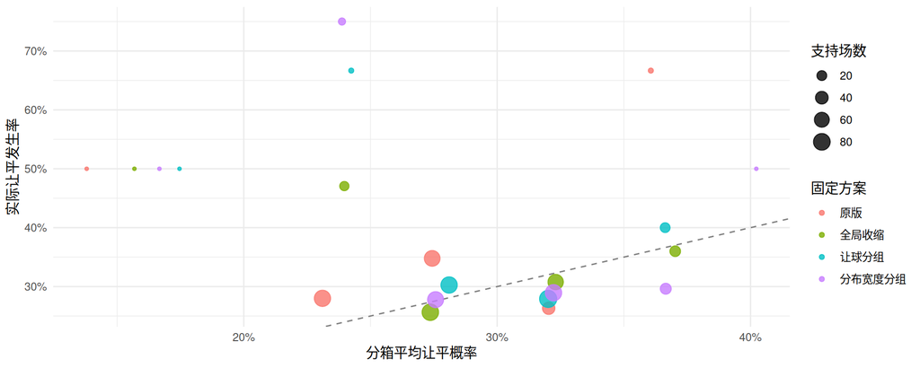

```r
cal <- read_csv(file.path(out,"calibration.csv"),show_col_types=FALSE)
cal |> filter(primary_estimated,model %in% c("FM171","GLOBAL_D48","LINE_D48","WIDTH_D48")) |>
 ggplot(aes(predicted,observed,colour=model,size=n)) + geom_abline(slope=1,intercept=0,linetype=2,colour="grey50") +
 geom_point(alpha=.8) + scale_colour_discrete(labels=c(FM171="原版",GLOBAL_D48="全局收缩",LINE_D48="让球分组",WIDTH_D48="分布宽度分组")) + scale_x_continuous(labels=scales::percent) + scale_y_continuous(labels=scales::percent) +
 labs(x="分箱平均让平概率",y="实际让平发生率",colour="固定方案",size="支持场数") + theme_minimal()
```

## 救回、误伤与分布位置

```r
knitr::kable(metrics |> filter(cohort=="PRIMARY_ESTIMATED",dimension=="draw_group") |>
 select(stratum,model,n,hits1,hits2,saved_top2,lost_top2,brier,draw_brier),digits=6)
```

| stratum | model | n | hits1 | hits2 | saved_top2 | lost_top2 | brier | draw_brier |
| --- | --- | --- | --- | --- | --- | --- | --- | --- |
| DRAW_BIN_OUTSIDE_TOP2 | FM171 | 5 | 3 | 4 | 0 | 0 | 0.525539 | 0.284316 |
| DRAW_BIN_TOP2_ALREADY_INCLUDED | FM171 | 78 | 32 | 56 | 0 | 0 | 0.696281 | 0.229460 |
| DRAW_BIN_TOP2_CATEGORY3 | FM171 | 104 | 42 | 75 | 0 | 0 | 0.672089 | 0.204198 |
| DRAW_BIN_OUTSIDE_TOP2 | GLOBAL_D48 | 5 | 3 | 5 | 1 | 0 | 0.516858 | 0.277062 |
| DRAW_BIN_TOP2_ALREADY_INCLUDED | GLOBAL_D48 | 78 | 32 | 56 | 0 | 0 | 0.691509 | 0.227906 |
| DRAW_BIN_TOP2_CATEGORY3 | GLOBAL_D48 | 104 | 43 | 78 | 18 | 15 | 0.669711 | 0.203207 |
| DRAW_BIN_OUTSIDE_TOP2 | GLOBAL_D72 | 5 | 3 | 5 | 1 | 0 | 0.508227 | 0.271826 |
| DRAW_BIN_TOP2_ALREADY_INCLUDED | GLOBAL_D72 | 78 | 32 | 56 | 0 | 0 | 0.691964 | 0.228242 |
| DRAW_BIN_TOP2_CATEGORY3 | GLOBAL_D72 | 104 | 43 | 76 | 16 | 15 | 0.670684 | 0.203798 |
| DRAW_BIN_OUTSIDE_TOP2 | LINE_D48 | 5 | 3 | 5 | 1 | 0 | 0.520532 | 0.277362 |
| DRAW_BIN_TOP2_ALREADY_INCLUDED | LINE_D48 | 78 | 31 | 56 | 0 | 0 | 0.690216 | 0.227586 |
| DRAW_BIN_TOP2_CATEGORY3 | LINE_D48 | 104 | 42 | 72 | 21 | 24 | 0.670382 | 0.204080 |
| DRAW_BIN_OUTSIDE_TOP2 | LINE_D72 | 5 | 3 | 5 | 1 | 0 | 0.511781 | 0.272254 |
| DRAW_BIN_TOP2_ALREADY_INCLUDED | LINE_D72 | 78 | 30 | 56 | 0 | 0 | 0.690072 | 0.227545 |
| DRAW_BIN_TOP2_CATEGORY3 | LINE_D72 | 104 | 42 | 70 | 19 | 24 | 0.671406 | 0.204712 |
| DRAW_BIN_OUTSIDE_TOP2 | WIDTH_D48 | 5 | 3 | 5 | 1 | 0 | 0.515289 | 0.275757 |
| DRAW_BIN_TOP2_ALREADY_INCLUDED | WIDTH_D48 | 78 | 30 | 56 | 0 | 0 | 0.692306 | 0.228092 |
| DRAW_BIN_TOP2_CATEGORY3 | WIDTH_D48 | 104 | 43 | 73 | 22 | 24 | 0.672448 | 0.205423 |
| DRAW_BIN_OUTSIDE_TOP2 | WIDTH_D72 | 5 | 3 | 5 | 1 | 0 | 0.505001 | 0.269420 |
| DRAW_BIN_TOP2_ALREADY_INCLUDED | WIDTH_D72 | 78 | 31 | 56 | 0 | 0 | 0.691719 | 0.227719 |
| DRAW_BIN_TOP2_CATEGORY3 | WIDTH_D72 | 104 | 43 | 73 | 20 | 22 | 0.673118 | 0.205737 |

```r
knitr::kable(metrics |> filter(cohort=="PRIMARY_ESTIMATED",dimension=="handicap_zero") |>
 select(stratum,model,n,hits1,hits2,saved_top2,lost_top2,brier,draw_brier),digits=6)
```

| stratum | model | n | hits1 | hits2 | saved_top2 | lost_top2 | brier | draw_brier |
| --- | --- | --- | --- | --- | --- | --- | --- | --- |
| NONZERO | FM171 | 93 | 36 | 66 | 0 | 0 | 0.692826 | 0.206674 |
| ZERO | FM171 | 94 | 41 | 69 | 0 | 0 | 0.663851 | 0.226971 |
| NONZERO | GLOBAL_D48 | 93 | 36 | 71 | 13 | 8 | 0.688971 | 0.205461 |
| ZERO | GLOBAL_D48 | 94 | 42 | 68 | 6 | 7 | 0.660614 | 0.225401 |
| NONZERO | GLOBAL_D72 | 93 | 36 | 70 | 12 | 8 | 0.689762 | 0.205967 |
| ZERO | GLOBAL_D72 | 94 | 42 | 67 | 5 | 7 | 0.660825 | 0.225555 |
| NONZERO | LINE_D48 | 93 | 36 | 66 | 17 | 17 | 0.688400 | 0.206129 |
| ZERO | LINE_D48 | 94 | 40 | 67 | 5 | 7 | 0.661043 | 0.225456 |
| NONZERO | LINE_D72 | 93 | 36 | 64 | 15 | 17 | 0.688902 | 0.206467 |
| ZERO | LINE_D72 | 94 | 39 | 67 | 5 | 7 | 0.661094 | 0.225515 |
| NONZERO | WIDTH_D48 | 93 | 36 | 66 | 16 | 16 | 0.691309 | 0.207390 |
| ZERO | WIDTH_D48 | 94 | 40 | 68 | 7 | 8 | 0.661907 | 0.226028 |
| NONZERO | WIDTH_D72 | 93 | 36 | 66 | 14 | 14 | 0.692080 | 0.207818 |
| ZERO | WIDTH_D72 | 94 | 41 | 68 | 7 | 8 | 0.660850 | 0.225305 |

```r
changes <- read_csv(file.path(out,"changes.csv"),show_col_types=FALSE)
knitr::kable(changes |> filter(grepl("D48$",model)),digits=4,caption="48h主时钟全部Top2救回/误伤；未挑选有利场次")
```

48h主时钟全部Top2救回/误伤；未挑选有利场次

| fixture_id | issue_id | home | away | model | handicap | actual_outcome | draw_probability | saved_top2 | lost_top2 | draw_group |
| --- | --- | --- | --- | --- | --- | --- | --- | --- | --- | --- |
| 26101:101 | 26101 | 宫崎特格瓦嘉洛 | RB大宫松鼠 | GLOBAL_D48 | 0 | D | 0.3110 | TRUE | FALSE | DRAW_BIN_TOP2_CATEGORY3 |
| 26101:105 | 26101 | 布莱尼 | 利恩 | GLOBAL_D48 | -1 | D | 0.2289 | TRUE | FALSE | DRAW_BIN_TOP2_CATEGORY3 |
| 26101:111 | 26101 | 威尔士 | 丹麦 | GLOBAL_D48 | 1 | D | 0.2566 | TRUE | FALSE | DRAW_BIN_TOP2_CATEGORY3 |
| 26101:14 | 26101 | 挪威U21 | 波黑U21 | GLOBAL_D48 | -2 | W | 0.2658 | FALSE | TRUE | DRAW_BIN_TOP2_CATEGORY3 |
| 26101:17 | 26101 | 斯洛文 | 北马其顿 | GLOBAL_D48 | -1 | W | 0.3071 | FALSE | TRUE | DRAW_BIN_TOP2_CATEGORY3 |
| 26101:2 | 26101 | 澳大利亚 | 巴西 | GLOBAL_D48 | 2 | D | 0.2607 | TRUE | FALSE | DRAW_BIN_TOP2_CATEGORY3 |
| 26101:23 | 26101 | 捷克 | 英格兰 | GLOBAL_D48 | 2 | D | 0.2554 | TRUE | FALSE | DRAW_BIN_TOP2_CATEGORY3 |
| 26101:24 | 26101 | 苏格兰 | 瑞士 | GLOBAL_D48 | 1 | L | 0.2821 | FALSE | TRUE | DRAW_BIN_TOP2_CATEGORY3 |
| 26101:25 | 26101 | 博塔弗戈SP | 庞特普雷 | GLOBAL_D48 | -2 | D | 0.2326 | TRUE | FALSE | DRAW_BIN_OUTSIDE_TOP2 |
| 26101:37 | 26101 | 新奥里藏蒂诺 | 戈亚斯 | GLOBAL_D48 | -1 | W | 0.2899 | FALSE | TRUE | DRAW_BIN_TOP2_CATEGORY3 |
| 26101:41 | 26101 | 拉脱维 | 黑山 | GLOBAL_D48 | 1 | D | 0.2843 | TRUE | FALSE | DRAW_BIN_TOP2_CATEGORY3 |
| 26101:47 | 26101 | 费恩哈普 | 凯里 | GLOBAL_D48 | 1 | D | 0.2598 | TRUE | FALSE | DRAW_BIN_TOP2_CATEGORY3 |
| 26101:48 | 26101 | 条约联 | 都柏林 | GLOBAL_D48 | 0 | L | 0.3159 | FALSE | TRUE | DRAW_BIN_TOP2_CATEGORY3 |
| 26101:49 | 26101 | 韦克斯福德 | 朗福德城 | GLOBAL_D48 | 0 | D | 0.3165 | TRUE | FALSE | DRAW_BIN_TOP2_CATEGORY3 |
| 26101:53 | 26101 | 圣保罗 | 桑托斯 | GLOBAL_D48 | 0 | L | 0.3204 | FALSE | TRUE | DRAW_BIN_TOP2_CATEGORY3 |
| 26101:56 | 26101 | 博卡青年 | 圣菲联合 | GLOBAL_D48 | -1 | W | 0.2689 | FALSE | TRUE | DRAW_BIN_TOP2_CATEGORY3 |
| 26101:63 | 26101 | 大分三神 | 山形山神 | GLOBAL_D48 | 0 | W | 0.3470 | FALSE | TRUE | DRAW_BIN_TOP2_CATEGORY3 |
| 26101:84 | 26101 | 阿尔梅里亚 | 布尔戈斯 | GLOBAL_D48 | -1 | D | 0.2586 | TRUE | FALSE | DRAW_BIN_TOP2_CATEGORY3 |
| 26101:91 | 26101 | 邓伯什 | 多德雷赫特 | GLOBAL_D48 | 0 | D | 0.2623 | TRUE | FALSE | DRAW_BIN_TOP2_CATEGORY3 |
| 26102:12 | 26102 | 波黑 | 波兰 | GLOBAL_D48 | 0 | W | 0.3341 | FALSE | TRUE | DRAW_BIN_TOP2_CATEGORY3 |
| 26102:27 | 26102 | 保加利亚U21 | 苏格兰U21 | GLOBAL_D48 | 0 | L | 0.3519 | FALSE | TRUE | DRAW_BIN_TOP2_CATEGORY3 |
| 26102:28 | 26102 | 丹麦U21 | 比利时U21 | GLOBAL_D48 | 0 | D | 0.3515 | TRUE | FALSE | DRAW_BIN_TOP2_CATEGORY3 |
| 26102:29 | 26102 | 威尔士U21 | 奥地利U21 | GLOBAL_D48 | 1 | L | 0.2764 | FALSE | TRUE | DRAW_BIN_TOP2_CATEGORY3 |
| 26102:35 | 26102 | 法罗群岛U21 | 冰岛U21 | GLOBAL_D48 | 2 | D | 0.2578 | TRUE | FALSE | DRAW_BIN_TOP2_CATEGORY3 |
| 26102:45 | 26102 | 格里姆斯比 | 伯顿 | GLOBAL_D48 | 0 | D | 0.3148 | TRUE | FALSE | DRAW_BIN_TOP2_CATEGORY3 |
| 26102:51 | 26102 | 斯蒂夫尼奇 | 莱斯特城 | GLOBAL_D48 | 0 | W | 0.3212 | FALSE | TRUE | DRAW_BIN_TOP2_CATEGORY3 |
| 26102:61 | 26102 | 克劳利 | 布罗姆利 | GLOBAL_D48 | 0 | W | 0.3020 | FALSE | TRUE | DRAW_BIN_TOP2_CATEGORY3 |
| 26102:63 | 26102 | 戈亚斯 | 米纳斯吉拉斯竞技 | GLOBAL_D48 | -1 | D | 0.3138 | TRUE | FALSE | DRAW_BIN_TOP2_CATEGORY3 |
| 26102:66 | 26102 | 庞特普雷 | 尤文图德 | GLOBAL_D48 | 2 | D | 0.2716 | TRUE | FALSE | DRAW_BIN_TOP2_CATEGORY3 |
| 26102:70 | 26102 | 雷莫 | 格雷米奥 | GLOBAL_D48 | 0 | D | 0.3466 | TRUE | FALSE | DRAW_BIN_TOP2_CATEGORY3 |

[output cut: 97 more lines]

## 核心质量已支持两侧的场景

用上轮固定90%核心的两侧质量定义core_blocks_draw：两侧核心各自已超过让平时，继续统一压尾不能将让平推入Top2。这只是解释性分层，不参与本轮拟合或选择阈值。

```r
scores <- read_csv(file.path(out,"scores.csv"),show_col_types=FALSE)
parent_eval <- jsonlite::fromJSON(file.path(root,"results/fm171-margin-shape-20261017/evaluation.json"))
contribution_path <- file.path(root,"results/fm171-margin-shape-20261017/contributions.csv")
stopifnot(digest::digest(file=contribution_path,algo="sha256")==parent_eval$output_hashes$contributions)
core_masses <- read_csv(contribution_path,show_col_types=FALSE) |> filter(core) |>
 select(fixture_id,outcome,mass) |> pivot_wider(names_from=outcome,values_from=mass,values_fill=0) |>
 mutate(core_blocks_draw=D<=pmin(W,L)+1e-12)
knitr::kable(scores |> filter(primary_estimated,model %in% c("FM171","GLOBAL_D48"),draw_group=="DRAW_BIN_TOP2_CATEGORY3") |>
 left_join(core_masses,by="fixture_id",relationship="many-to-one") |> group_by(core_blocks_draw,model) |>
 summarise(n=n(),hits1=sum(top1),hits2=sum(top2),saved=sum(saved_top2),lost=sum(lost_top2),brier=mean(brier),.groups="drop"),digits=6)
```

| core_blocks_draw | model | n | hits1 | hits2 | saved | lost | brier |
| --- | --- | --- | --- | --- | --- | --- | --- |
| FALSE | FM171 | 25 | 8 | 16 | 0 | 0 | 0.698042 |
| FALSE | GLOBAL_D48 | 25 | 9 | 17 | 9 | 8 | 0.684006 |
| TRUE | FM171 | 79 | 34 | 59 | 0 | 0 | 0.663876 |
| TRUE | GLOBAL_D48 | 79 | 34 | 61 | 9 | 7 | 0.665187 |

核心主导的79场中，全局校正救回9场、误伤7场，Top2净增2场，但该子组全三类Brier略变差。历史校正能改变核心内质量，数学上不受纯尾压缩的限制；不过选择改善不等于该子组概率更准确。尾部可改变排序的25场则净增1场。两个子组全部展示，不将有利子组当作独立验证。

## 局限与后续判据

本轮校正针对一条实际北单让球线定义的事件。虽然校正后仍有完整比分网格、可作任意让球的数学投影，但尚未验证其他让球线上的校准；更换目标h后重新拟合会得到另一份条件分布，不能把它当作与h无关的统一战力校准。这是新增研究层的局限，原FM171的lambda/核心仍不使用北单线。若要升级为统一比分校准，需另行检验多个净胜球档的联合一致性，而非逐线反复抬让平。

此数据量只能检验低维收缩，不足以研究联赛×让球×阵容×总进球等细粒度条件发生率。后验收缩强度、分组与48h/72h代理并非已验证的业务参数；所有方案全部报告，没有根据这三期挑最佳升级正式版本。候选分组来自此前已知结果的讨论与形态探索，固定参数并不使其成为独立的事前研究。分布形态分组粗糙、期际状态不同、同期比赛相关、已有多次复盘及历史代理都会限制推广。没有声称显著性或独立置信区间。

如果只在个别期改善，或Top2改善却整体概率评分恶化，不足以形成通用校正。下一阶段需更长的同版、截止绑定预测与真实标签可用性，再用独立未来期验证；不能用更多纯赛果替代缺失的同版预测，也不能把旧版概率直接混作同版校准样本。未生成票单，不评价收益。

## 复现与验收

精确R/Python/依赖版本和测试环境在runtime.json、test-environment.json；受限环境下Quarto样式缓存显式放在可写的/tmp/fm171-draw-quarto-cache，未改HOME。不在函数或渲染时安装依赖。R4.6.1、项目.venv/bin/python，正常安装的r_lib/beidan；本轮无packages/beidan变更，无须新装包或重跑未受影响的独立Python套件。完整仓库入口同时检查正常安装包及其DLL，无手工dyn.load/load_all。没有CI操作。

```bash
TZ=UTC Rscript r/fm171_draw_history_freeze.R ROOT OUTPUT
TZ=UTC Rscript r/fm171_draw_history_freeze.R ROOT OUTPUT replay
TZ=UTC Rscript r/fm171_draw_history_evaluate.R ROOT OUTPUT
TZ=UTC Rscript tests/testthat.R
TZ=UTC XDG_CACHE_HOME=/tmp/fm171-draw-quarto-cache QUARTO_R=/opt/R/4.6.1/bin/R quarto render quarto/fm171_draw_history_20261017.qmd --no-cache
```

新测试test-fm171-draw-history.R映射：域收缩计算与分组→独立重算全体参数、模型/经验质量、权重与支持；时序/来源→提名快照拒绝伪提前目标/未来期，实际共享上下文排除目标/截止后数据，并从客户端真实拟合表达式证明后截止标签变异不改变参数/预测、但缓存key变化；比分映射→每场完整网格、W/L及条件比分比率；评分→六CSV独立重放、配对误伤/救回对账及篡改拒绝。无新项目函数或复制时序工具，只有有界客户端域拟合/预测编排。Pandas扩展字符串转换在实际全量冻结及重放中覆盖；早期开发发现的转换问题已在最终实现修复，不靠跳过断言。

```r
if(isTRUE(params$acceptance_required)) {
 a <- jsonlite::fromJSON(file.path(out,"acceptance.json"))
 stopifnot(a$status=="ACCEPTED",a$blocking_findings==0L)
 for(i in seq_len(nrow(a$files)))stopifnot(digest::digest(file=file.path(root,a$files$path[i]),algo="sha256")==a$files$sha256[i])
 knitr::kable(as_tibble(a$checks),caption="最终源码SHA256、精确检查命令、退出状态与审查证据")
} else cat("预览：完整验收未完成。")
```

最终源码SHA256、精确检查命令、退出状态与审查证据

| command | result |
| --- | --- |
| TZ=UTC /opt/R/4.6.1/bin/Rscript r/fm171_draw_history_freeze.R ROOT OUTPUT; repeat with replay; R_LIBS in runtime.json | Both exit0;323 fixtures FULL_IDENTICAL_REPLAY; only nominated prior snapshots/shared-admitted rows fitted. Forecasts frozen before this evaluator. Retrospective label catalog was opened; no blind-test… |
| TZ=UTC /opt/R/4.6.1/bin/Rscript r/fm171_draw_history_evaluate.R ROOT OUTPUT | Exit0; ALL322 and primary estimated cohorts; all3models x2proxyclocks; no selected production rule. Six CSV independent replay verified by targeted tests |
| DRAW_TARGETED=1 .venv/bin/python results/fm171-draw-calibration-20261017/verification-runner.py | {“tests”: 3, “passed”: 31664, “failed”: 0, “errors”: 0, “warnings”: 0, “skipped”: 0}; covers full-grid contracts, independently recalculated shrinkage, source nomination, actual clock audit, shared po… |
| .venv/bin/python results/fm171-draw-calibration-20261017/verification-runner.py -> /opt/R/4.6.1/bin/Rscript tests/testthat.R; exact env in test-environment.json | {“package”: {“tests”: 948, “passed”: 9153, “failed”: 0, “errors”: 0, “warnings”: 0, “skipped”: 0}, “repository”: {“tests”: 791, “passed”: 172872, “failed”: 0, “errors”: 0, “warnings”: 0, “skipped”: 2}… |
| Unverified cases, not passed | Two unrelated #408 integration-bundle cases, test-fundamentals-pipeline.R lines6 and44: integration bundle must be materialized by test setup. All new draw-history cases executed |
| Source/runtime scope | No packages/beidan code change in this delivery; normally installed r_lib/beidan used throughout, full R tests cover installed DLL wrappers. No manual dyn.load/load_all. No new package installation or… |
| codex review ‘Final source/numerical review only historical draw calibration study: config/fm171_draw_history_study.json, r/fm171_draw_history_freeze.R, r/fm171_draw_history_evaluate.R, tests/testthat… | No actionable defects; exact current source hashes recorded below. Full-suite outcomes verified separately |
| TZ=UTC XDG_CACHE_HOME=/tmp/fm171-draw-quarto-cache QUARTO_R=/opt/R/4.6.1/bin/R quarto render quarto/fm171_draw_history_20261017.qmd –no-cache | Exit0; clean-session render;9 tables,1 inspected figure,0 execution errors; source and forecast hashes verified; final HTML SHA256 in html-validation.json |
| Availability and research limitation | Three already-discussed issues; no older same-version ready history. Proxy decision+48h/+72h admission is diagnostic only. Observed label clocks audited separately; historical predictor availability a… |
| Development conversion/recovery | Pandas3 Arrow strings converted via records JSON(15 decimals/ISO) into typed validated R tibbles; integer Python API arguments explicit. Excluded development prototype preserved outside active source … |
| Reviewed/imported SHA256: config/fm171_draw_history_study.json | 26292611dc3eaca6db6bce8e09bb9e39c565dfe0c7ed9710080a11d2c8f995d7 |
| Reviewed/imported SHA256: r/fm171_draw_history_freeze.R | 92d2434567d433b7ea8bca5cd4473215506b46e95310c6d175321b1221916851 |
| Reviewed/imported SHA256: r/fm171_draw_history_evaluate.R | 161041d14f3c5c1478b51d7d30961ca56e79760ad1ac88293340068a76f9aee7 |
| Reviewed/imported SHA256: tests/testthat/test-fm171-draw-history.R | 80d467967ae2822297fd1fad02b8b5ce87d0d82be8bb2244cc652beee37b3e91 |
| Reviewed/imported SHA256: quarto/fm171_draw_history_20261017.qmd | 21b4a53db8d225ccd30ee64b668044d7515b1d0237d0f91c6c0633390456b8e4 |
| Reviewed/imported SHA256: results/fm171-draw-calibration-20261017/verification-runner.py | 3059a20f32441b1702d6f37b3d4c7ffe9f75a5f9c6f8f40f7414eac7244daf6f |
| Reviewed/imported SHA256: packages/beidan/R/dc_accuracy_diagnostic.R | 371cb42c60a4920fa122283f309a1151b0319959db892daa4fbc3bb92e61970d |
| Normal-permission complete R rerun after sandbox failure | Exit0. Prior sandbox run failed solely on Quarto cache and repository-external temporary directory permissions; no code/test changes. Full rerun passed; see full-R-tests.log |